title: “Corporacion Grocery Sales EDA”

#Introduction

#Read the Data

#Peek into the Train Data

```r
head(train)
```

```
## # A tibble: 6 x 6
##      id date       store_nbr item_nbr unit_sales onpromotion
##   <int> <date>         <int>    <int>      <dbl> <lgl>
## 1     0 2013-01-01        25   103665          7 NA
## 2     1 2013-01-01        25   105574          1 NA
## 3     2 2013-01-01        25   105575          2 NA
## 4     3 2013-01-01        25   108079          1 NA
## 5     4 2013-01-01        25   108701          1 NA
## 6     5 2013-01-01        25   108786          3 NA
```

#Test Data - Unique Store and Item Combinations

```r
TestUniqueGroups = test %>%
  group_by(store_nbr,item_nbr) %>%
  tally()

cat ("The number of Unique Store and Item Combinations is ",nrow(unique(TestUniqueGroups)))
```

```
## The number of Unique Store and Item Combinations is  210654
```

#Stores {.tabset .tabset-pills .tabset-fade}

```r
kable(head(stores),"html") %>%
  kable_styling(bootstrap_options = c("striped", "hover", "condensed", "responsive")) %>%
  scroll_box(width = "800px")
```

| store_nbr | city | state | type | cluster |
| --- | --- | --- | --- | --- |
| 1 | Quito | Pichincha | D | 13 |
| 2 | Quito | Pichincha | D | 13 |
| 3 | Quito | Pichincha | D | 8 |
| 4 | Quito | Pichincha | D | 9 |
| 5 | Santo Domingo | Santo Domingo de los Tsachilas | D | 4 |
| 6 | Quito | Pichincha | D | 13 |

##Cities and Stores

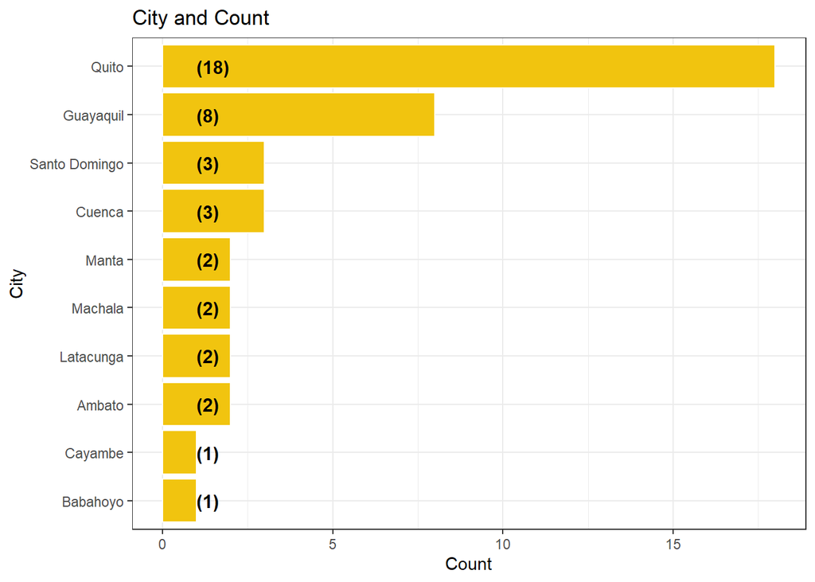

```r
stores %>%
  group_by(city) %>%
  summarise(Count = n()) %>%
  ungroup() %>%
  mutate(city = reorder(city,Count)) %>%
  arrange(desc(Count)) %>%
  head(10) %>%

  ggplot(aes(x = city,y = Count)) +
  geom_bar(stat='identity',colour="white", fill = fillColor2) +
  geom_text(aes(x = city, y = 1, label = paste0("(",Count,")",sep="")),
            hjust=0, vjust=.5, size = 4, colour = 'black',
            fontface = 'bold') +
  labs(x = 'City',
       y = 'Count',
       title = 'City and Count') +
  coord_flip() +
  theme_bw()
```

##State and Stores

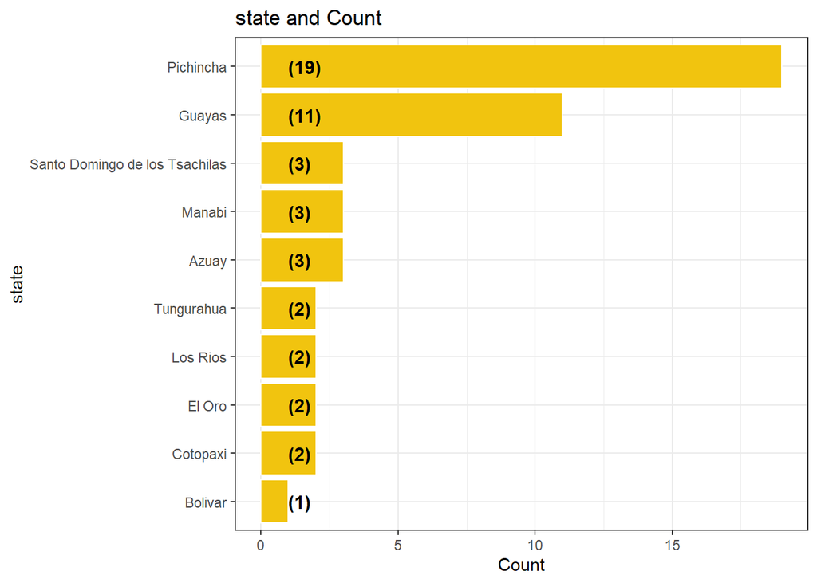

```r
stores %>%
  group_by(state) %>%
  summarise(Count = n()) %>%
  ungroup() %>%
  mutate(state = reorder(state,Count)) %>%
  arrange(desc(Count)) %>%
  head(10) %>%

  ggplot(aes(x = state,y = Count)) +
  geom_bar(stat='identity',colour="white", fill = fillColor2) +
  geom_text(aes(x = state, y = 1, label = paste0("(",Count,")",sep="")),
            hjust=0, vjust=.5, size = 4, colour = 'black',
            fontface = 'bold') +
  labs(x = 'state',
       y = 'Count',
       title = 'state and Count') +
  coord_flip() +
  theme_bw()
```

##Cluster and Stores

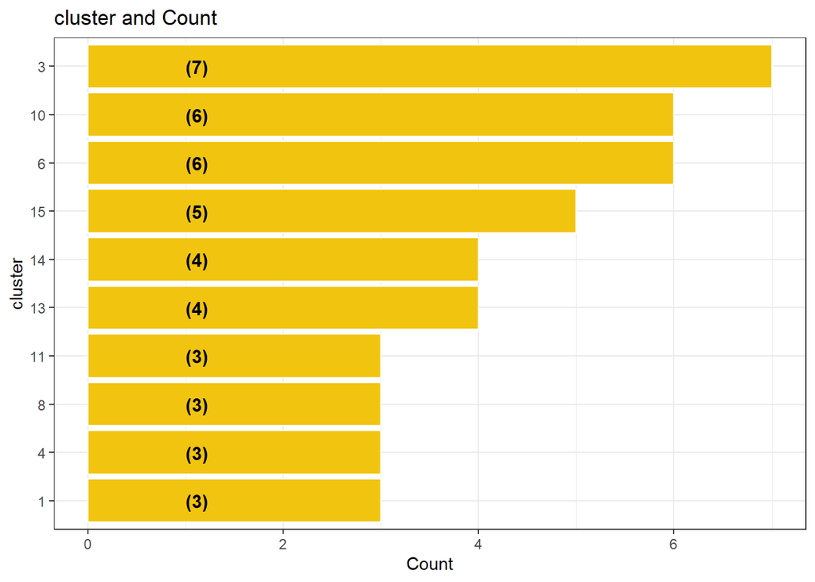

```r
stores %>%
  group_by(cluster) %>%
  summarise(Count = n()) %>%
  ungroup() %>%
  mutate(cluster = reorder(cluster,Count)) %>%
  arrange(desc(Count)) %>%
  head(10) %>%

  ggplot(aes(x = cluster,y = Count)) +
  geom_bar(stat='identity',colour="white", fill = fillColor2) +
  geom_text(aes(x = cluster, y = 1, label = paste0("(",Count,")",sep="")),
            hjust=0, vjust=.5, size = 4, colour = 'black',
            fontface = 'bold') +
  labs(x = 'cluster',
       y = 'Count',
       title = 'cluster and Count') +
  coord_flip() +
  theme_bw()
```

#Top 10 Selling Stores

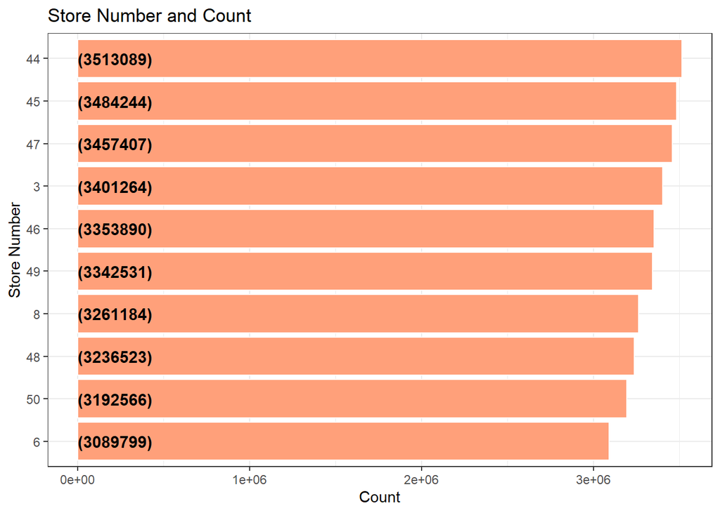

```r
train %>%
  group_by(store_nbr) %>%
  summarise(Count = n()) %>%
  ungroup() %>%
  mutate(store_nbr = reorder(store_nbr,Count)) %>%
  arrange(desc(Count)) %>%
  head(10) %>%

  ggplot(aes(x = store_nbr,y = Count)) +
  geom_bar(stat='identity',colour="white", fill = fillColor) +
  geom_text(aes(x = store_nbr, y = 1, label = paste0("(",Count,")",sep="")),
            hjust=0, vjust=.5, size = 4, colour = 'black',
            fontface = 'bold') +
  labs(x = 'Store Number',
       y = 'Count',
       title = 'Store Number and Count') +
  coord_flip() +
  theme_bw()
```

#Where are the Top 10 Selling Stores ?

```r
Top10Stores = train %>%
  group_by(store_nbr) %>%
  summarise(Count = n()) %>%
  arrange(desc(Count)) %>%
  head(10)

Top10StoresDescription = inner_join(Top10Stores,stores)

kable(Top10StoresDescription,"html") %>%
  kable_styling(bootstrap_options = c("striped", "hover", "condensed", "responsive")) %>%
  scroll_box(width = "800px")
```

| store_nbr | Count | city | state | type | cluster |
| --- | --- | --- | --- | --- | --- |
| 44 | 3513089 | Quito | Pichincha | A | 5 |
| 45 | 3484244 | Quito | Pichincha | A | 11 |
| 47 | 3457407 | Quito | Pichincha | A | 14 |
| 3 | 3401264 | Quito | Pichincha | D | 8 |
| 46 | 3353890 | Quito | Pichincha | A | 14 |
| 49 | 3342531 | Quito | Pichincha | A | 11 |
| 8 | 3261184 | Quito | Pichincha | D | 8 |
| 48 | 3236523 | Quito | Pichincha | A | 14 |
| 50 | 3192566 | Ambato | Tungurahua | A | 14 |
| 6 | 3089799 | Quito | Pichincha | D | 13 |

#Top 10 Selling Items in Store Number 44 ( Highest Selling Store)

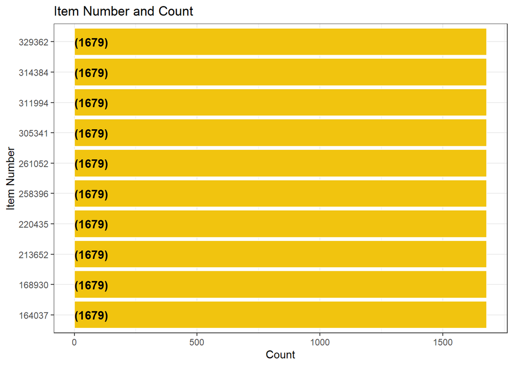

```r
train %>%
  filter(store_nbr == 44) %>%
  filter(!is.na(item_nbr)) %>%
  group_by(item_nbr) %>%
  summarise(Count = n()) %>%
  ungroup() %>%
  mutate(item_nbr = reorder(item_nbr,Count)) %>%

  arrange(desc(Count)) %>%
  head(10) %>%

  ggplot(aes(x = item_nbr,y = Count)) +
  geom_bar(stat='identity',colour="white", fill = fillColor2) +
  geom_text(aes(x = item_nbr, y = 1, label = paste0("(",Count,")",sep="")),
            hjust=0, vjust=.5, size = 4, colour = 'black',
            fontface = 'bold') +
  labs(x = 'Item Number',
       y = 'Count',
       title = 'Item Number and Count') +
  coord_flip() +
  theme_bw()
```

#Where are the Top 10 Selling Families in the Top Selling Store ?

```r
Top10Items = train %>%
  filter(store_nbr == 44) %>%
  filter(!is.na(item_nbr)) %>%
  group_by(item_nbr) %>%
  summarise(Count = n()) %>%
  ungroup() %>%
  arrange(desc(Count)) %>%
  head(10)

Top10ItemsDescription = inner_join(Top10Items,items,by="item_nbr")

kable(Top10ItemsDescription,"html") %>%
  kable_styling(bootstrap_options = c("striped", "hover", "condensed", "responsive")) %>%
  scroll_box(width = "800px")
```

| item_nbr | Count | family | class | perishable |
| --- | --- | --- | --- | --- |
| 164037 | 1679 | GROCERY I | 1048 | 0 |
| 168930 | 1679 | CLEANING | 3026 | 0 |
| 213652 | 1679 | GROCERY I | 1048 | 0 |
| 220435 | 1679 | GROCERY I | 1080 | 0 |
| 258396 | 1679 | GROCERY I | 1010 | 0 |
| 261052 | 1679 | GROCERY I | 1072 | 0 |
| 305341 | 1679 | GROCERY I | 1092 | 0 |
| 311994 | 1679 | BREAD/BAKERY | 2752 | 1 |
| 314384 | 1679 | GROCERY I | 1004 | 0 |
| 329362 | 1679 | GROCERY I | 1032 | 0 |

# Trend of Sales of Highest Selling Item in Highest Selling Store

This is the Trend of Sales of Item Number 329362 in Store Number 44

## Year and Month Wise Trends

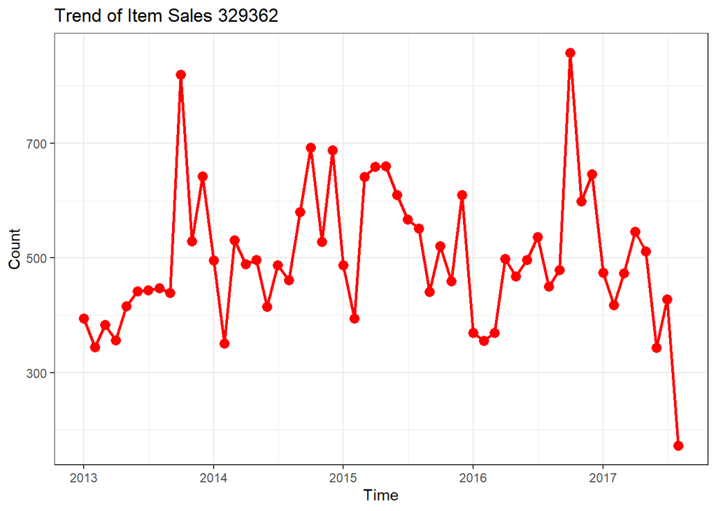

```r
train %>%
  filter(store_nbr == 44) %>%
  filter(item_nbr == 329362) %>%
  mutate(year = year(ymd(date))) %>%
  mutate(month = month(ymd(date)))  %>%

  filter(!is.na(year)) %>%
  filter(!is.na(month)) %>%
  group_by(year,month) %>%
  summarise(Count = sum(unit_sales)) %>%
  mutate(YearMonth = make_date(year=year,month=month) ) %>%

  ggplot(aes(x=YearMonth,y=Count,group = 1)) +
  geom_line(size=1, color="red")+
  geom_point(size=3, color="red") +

  labs(x = 'Time', y = 'Count',title = 'Trend of Item Sales 329362') +
  theme_bw()
```

## Top Selling Months

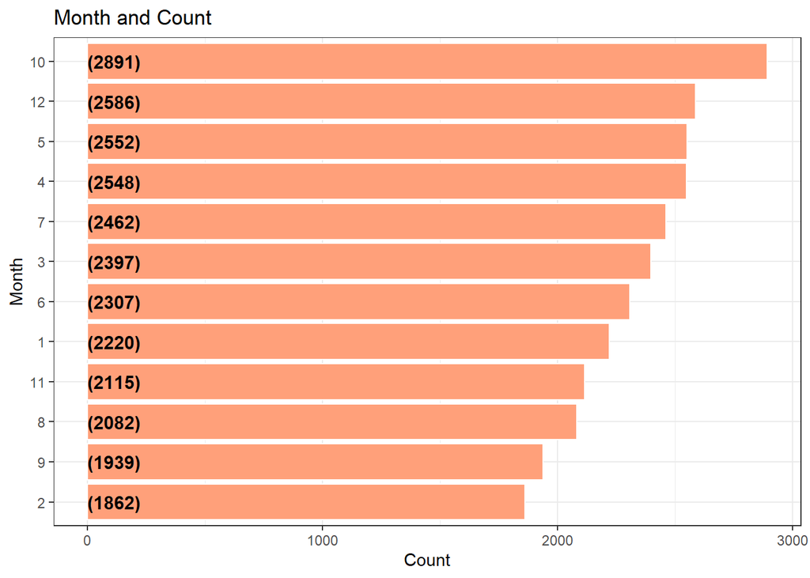

```r
train %>%
  filter(store_nbr == 44) %>%
  filter(item_nbr == 329362) %>%

  mutate(month = month(ymd(date)))  %>%

  mutate(dayOfWeek = wday(date, label = TRUE))  %>%

  filter(!is.na(year)) %>%
  filter(!is.na(month)) %>%
  group_by(month) %>%
  summarise(Count = sum(unit_sales)) %>%
  mutate(month = reorder(month,Count)) %>%

  ggplot(aes(x = month,y = Count)) +
  geom_bar(stat='identity',colour="white", fill = fillColor) +
  geom_text(aes(x = month, y = 1, label = paste0("(",Count,")",sep="")),
            hjust=0, vjust=.5, size = 4, colour = 'black',
            fontface = 'bold') +
  labs(x = 'Month',
       y = 'Count',
       title = 'Month and Count') +
  coord_flip() +
  theme_bw()
```

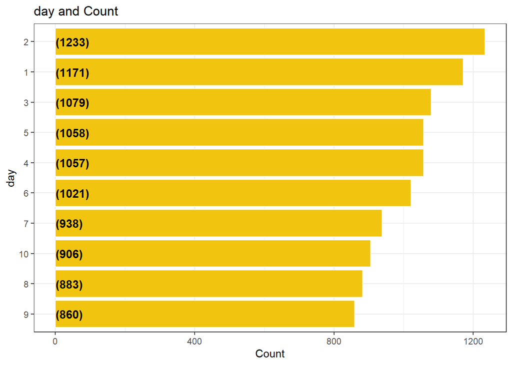

```r
train %>%
  filter(store_nbr == 44) %>%
  filter(item_nbr == 329362) %>%

  mutate(day = day(ymd(date))) %>%

  group_by(day) %>%
  summarise(Count = sum(unit_sales)) %>%
  mutate(day = reorder(day,Count)) %>%
  head(10) %>%

  ggplot(aes(x = day,y = Count)) +
  geom_bar(stat='identity',colour="white", fill = fillColor2) +
  geom_text(aes(x = day, y = 1, label = paste0("(",Count,")",sep="")),
            hjust=0, vjust=.5, size = 4, colour = 'black',
            fontface = 'bold') +
  labs(x = 'day',
       y = 'Count',
       title = 'day and Count') +
  coord_flip() +
  theme_bw()
```

## Top Selling Days in a Week

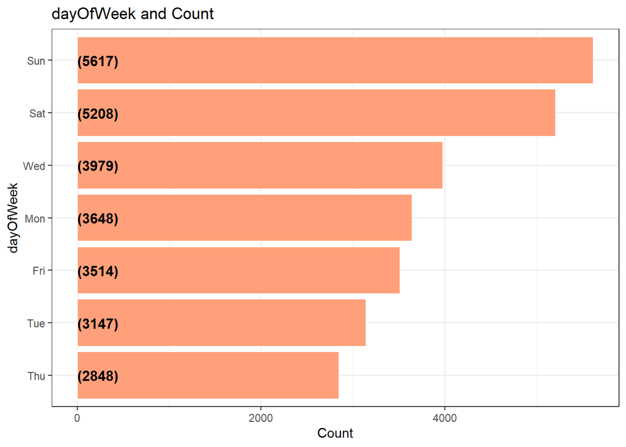

```r
train %>%
  filter(store_nbr == 44) %>%
  filter(item_nbr == 329362) %>%
  mutate(dayOfWeek = wday(date, label = TRUE))  %>%

  group_by(dayOfWeek) %>%
  summarise(Count = sum(unit_sales)) %>%
  mutate(dayOfWeek = reorder(dayOfWeek,Count)) %>%

  ggplot(aes(x = dayOfWeek,y = Count)) +
  geom_bar(stat='identity',colour="white", fill = fillColor) +
  geom_text(aes(x = dayOfWeek, y = 1, label = paste0("(",Count,")",sep="")),
            hjust=0, vjust=.5, size = 4, colour = 'black',
            fontface = 'bold') +
  labs(x = 'dayOfWeek',
       y = 'Count',
       title = 'dayOfWeek and Count') +
  coord_flip() +
  theme_bw()
```

#Items

```r
kable(head(items),"html") %>%
  kable_styling(bootstrap_options = c("striped", "hover", "condensed", "responsive")) %>%
  scroll_box(width = "800px")
```

| item_nbr | family | class | perishable |
| --- | --- | --- | --- |
| 96995 | GROCERY I | 1093 | 0 |
| 99197 | GROCERY I | 1067 | 0 |
| 103501 | CLEANING | 3008 | 0 |
| 103520 | GROCERY I | 1028 | 0 |
| 103665 | BREAD/BAKERY | 2712 | 1 |
| 105574 | GROCERY I | 1045 | 0 |

##Most Common Families in Items

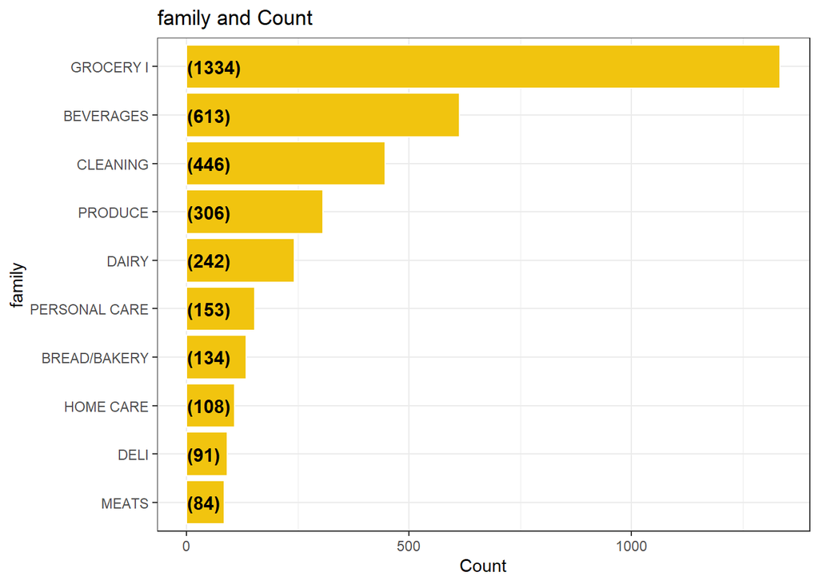

```r
items %>%
  group_by(family) %>%
  summarise(Count = n()) %>%
  ungroup() %>%
  mutate(family = reorder(family,Count)) %>%
  arrange(desc(Count)) %>%
  head(10) %>%

  ggplot(aes(x = family,y = Count)) +
  geom_bar(stat='identity',colour="white", fill = fillColor2) +
  geom_text(aes(x = family, y = 1, label = paste0("(",Count,")",sep="")),
            hjust=0, vjust=.5, size = 4, colour = 'black',
            fontface = 'bold') +
  labs(x = 'family',
       y = 'Count',
       title = 'family and Count') +
  coord_flip() +
  theme_bw()
```

#Dirty XGBoost and Feature Importance for Store Number 44 and Item Number 329362

We do a XGBoost on the following features

- year
- month
- day of the month
- day of the week
- oil price
- National Holiday or not

We do a `Five Fold` Cross Validation on the data set and also find the feature importance of the variables.

We also do `predictions` for the test set using the XGBoost Model

```r
TransformColumn = function(x)
{
  if (is.na(x))
  {
    return (0)
  }
  else
  {
    return (x)
  }
}

GetHighestSoldItem = function(ds,ItemNumber,StoreNumber)
{

  HighestSoldItem = ds %>%
    filter(store_nbr == StoreNumber) %>%
    filter(item_nbr == ItemNumber) %>%
    mutate(year = year(ymd(date)))  %>%
    mutate(month = month(ymd(date)))  %>%
    mutate(dayOfWeek = wday(date))  %>%
    mutate(day = day(ymd(date)))

  HighestSoldItem = left_join(HighestSoldItem,oil)

  HolidaysNational = holidays %>%
    filter(type != "Work Day") %>%
    filter(locale == "National")

  HighestSoldItem = left_join(HighestSoldItem,HolidaysNational, by = "date")

  HighestSoldItem = HighestSoldItem %>%
    select( -locale,-locale_name,-description,-transferred)

  HighestSoldItem = HighestSoldItem %>%
    select(-id,-store_nbr,-item_nbr,-date,-onpromotion)

  HighestSoldItem$type = sapply(HighestSoldItem$type,TransformColumn)

  features <- colnames(HighestSoldItem)

  for (f in features) {
    if ((class(HighestSoldItem[[f]])=="factor") || (class(HighestSoldItem[[f]])=="character")) {
      levels <- unique(HighestSoldItem[[f]])
      HighestSoldItem[[f]] <- as.numeric(factor(HighestSoldItem[[f]], levels=levels))
    }
  }



  return(HighestSoldItem)


}

HighestSoldItem = GetHighestSoldItem(train,329362,44)

HighestSoldItemTest = GetHighestSoldItem(test,329362,44)


formula = unit_sales ~ .

fitControl <- trainControl(method="cv",number = 5)


PlotImportance = function(importance)
{
  varImportance <- data.frame(Variables = row.names(importance[[1]]),
                              Importance = round(importance[[1]]$Overall,2))

  # Create a rank variable based on importance
  rankImportance <- varImportance %>%
    mutate(Rank = paste0('#',dense_rank(desc(Importance))))

  rankImportancefull = rankImportance

  ggplot(rankImportance, aes(x = reorder(Variables, Importance),
                             y = Importance)) +
    geom_bar(stat='identity',colour="white", fill = fillColor) +
    geom_text(aes(x = Variables, y = 1, label = Rank),
              hjust=0, vjust=.5, size = 4, colour = 'black',
              fontface = 'bold') +
    labs(x = 'Variables', title = 'Relative Variable Importance') +
    coord_flip() +
    theme_bw()


}


xgbGrid <- expand.grid(nrounds = 500,
                       max_depth = 4,
                       eta = .05,
                       gamma = 0,
                       colsample_bytree = .5,
                       min_child_weight = 1,
                       subsample = 1)

set.seed(13)

XGBModel = train(formula, data = HighestSoldItem,
                            method = "xgbTree",trControl = fitControl,
                            tuneGrid = xgbGrid,na.action = na.pass,metric="RMSE")
```

[output not shown]

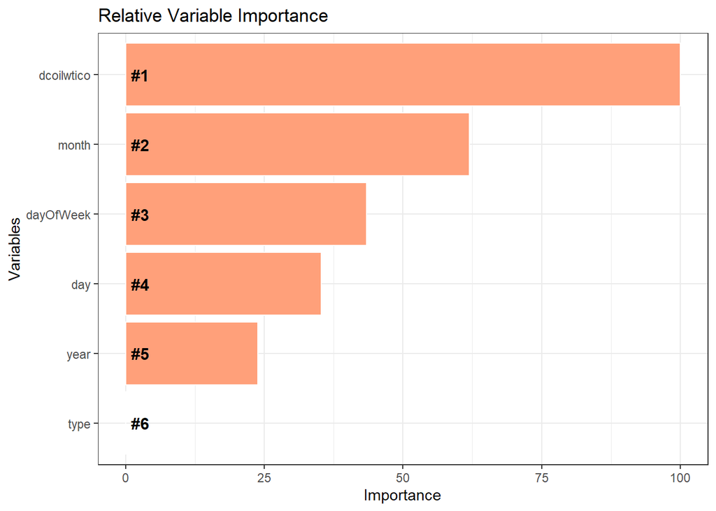

```r
importance = varImp(XGBModel)

PlotImportance(importance)
```

```r
predictions = round(predict(XGBModel,HighestSoldItemTest))


cat("The predictions are ","\n")
```

```
## The predictions are
```

```r
predictions
```

```
##  [1] 11  8  9 13 11 11  8 10 11 12 13  7
```

#Dirty Arima for Store Number 44 and Item Number 329362

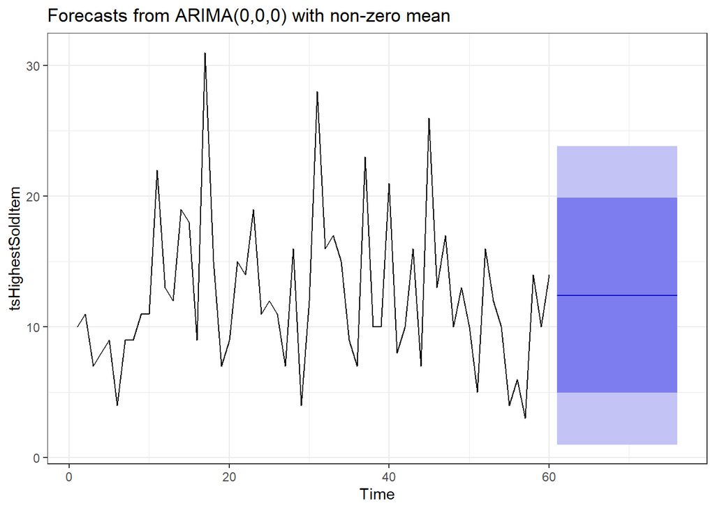

```r
HighestSoldItem = train %>%
  filter(store_nbr == 44) %>%
  filter(item_nbr == 329362) %>%
  arrange(desc(date)) %>%
  select(unit_sales) %>% head(60)

tsHighestSoldItem = ts(HighestSoldItem)

fit <- auto.arima(tsHighestSoldItem)

preds = forecast(fit, h = 16)

preds %>% autoplot(include=60) +theme_bw()
```

```r
predictions = round(as.numeric(preds$mean))

cat("The predictions are ","\n")
```

```
## The predictions are
```

```r
predictions
```

```
##  [1] 12 12 12 12 12 12 12 12 12 12 12 12 12 12 12 12
```

#Dirty ETS for Store Number 44 and Item Number 329362

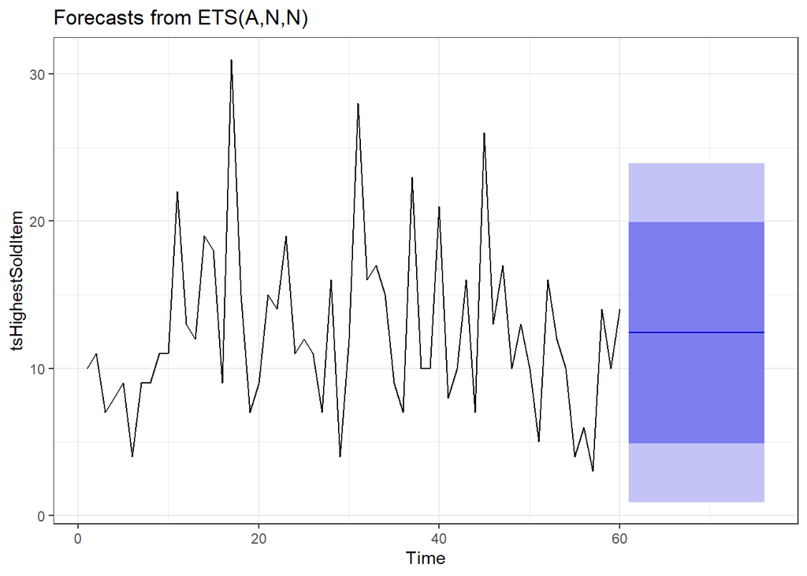

```r
fit <- ets(tsHighestSoldItem)

preds = forecast(fit, h = 16)

preds %>% autoplot(include=60) +theme_bw()
```

```r
predictions = round(as.numeric(preds$mean))

cat("The predictions are ","\n")
```

```
## The predictions are
```

```r
predictions
```

```
##  [1] 12 12 12 12 12 12 12 12 12 12 12 12 12 12 12 12
```

#Dirty Prophet for Store Number 44 and Item Number 329362

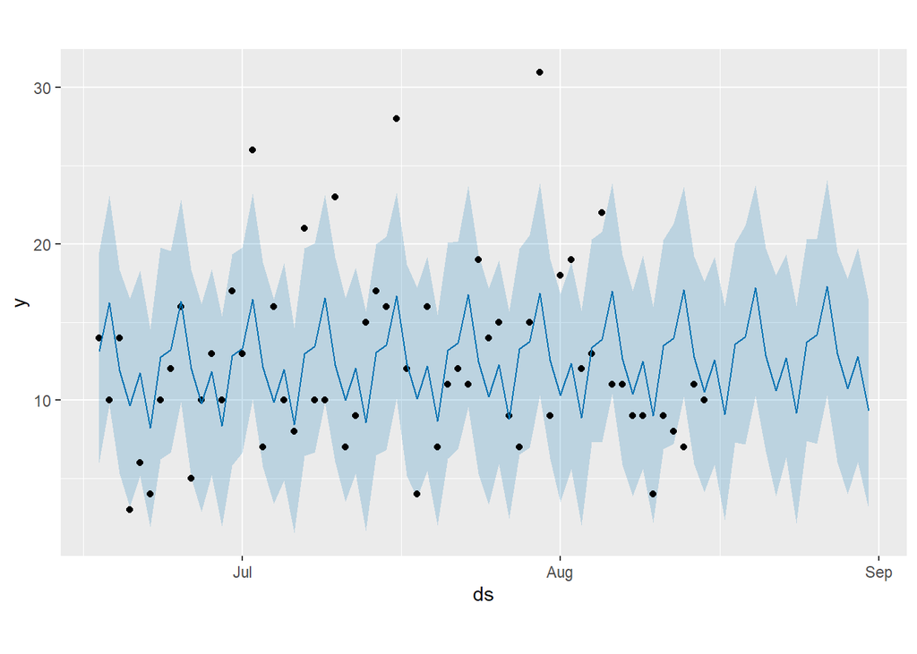

```r
HighestSoldItem = train %>%
  filter(store_nbr == 44) %>%
  filter(item_nbr == 329362) %>%
  arrange(desc(date)) %>%
  select(date,unit_sales) %>% head(60)

colnames(HighestSoldItem) = c("ds","y")

m <- prophet(HighestSoldItem,changepoint.prior.scale = 0.1)

future <- make_future_dataframe(m, periods = 16,freq = "day")

forecast <- predict(m, future)

predictions = tail(round(forecast$yhat),16)

plot(m, forecast)
```

```r
cat("The predictions are ","\n")
```

```
## The predictions are
```

```r
predictions
```

```
##  [1] 13  9 14 14 17 13 11 13  9 14 14 17 13 11 13  9
```

## Break into the Prophet Components

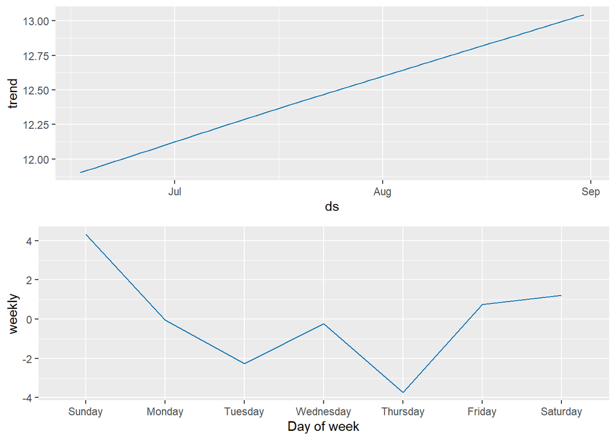

```r
prophet_plot_components(m, forecast)
```